# Linear Models Project: Student Performance Analysis

M1-MIDO, 2025-2026

Author

Lyes Bouchoucha, Samuel Yaiche, Noam Haddad

Published

January 22, 2026

# 1 Introduction

## 1.1 Context and Problem Statement

Academic success is shaped by behavioral, environmental, and socioeconomic factors. Understanding which factors are most strongly associated with student performance helps get better results. Intuition suggests that “studying more leads to better grades,” but the reality is more nuanced because the effectiveness of study time may depend on other factors such as sleep quality and apparent effects may be confounded by socioeconomic background.

This project analyzes data from $n = 5{,}000$ students to identify predictors of exam scores using multiple linear regression. The primary objectives are : (1) build a model that quantifies the association between student characteristics and exam performance, (2) assess whether model assumptions are satisfied, and (3) evaluate predictive performance on held-out data to guard against overfitting.

## 1.2 Dataset Description

The dataset contains 16 variables :

- **Response variable**: `y` — Exam score (continuous, scale 0–100)
- **Continuous predictors**: `age` (years), `study_hrs` (daily study hours), `sleep_hrs` (sleep duration), `attend_pct` (attendance rate in %)
- **Categorical predictors**: `sexe` (gender), `school_type` (public/private), `parent_educ` (parental education, 6 levels), `sleep_qual` (sleep quality, 3 levels), `trav_time` (commute time, 4 levels), `web_access` (internet access), `extra_act` (extracurricular activities), `study_method` (6 categories)

Two additional variables (`agecat`, `attend_pct_cat`) represent discretized versions of continuous predictors.

## 1.3 Research Hypotheses

We formulate the following hypotheses to guide our analysis:

1. **Study effort matters**: Students who study more and attend class more regularly should perform better on exams. We expect positive coefficients for `study_hrs` and `attend_pct`.
2. **Sleep quality has a strong effect on study effectiveness**: The benefits of study hours may depend on sleep quality, indeed a well-rested student may convert study time into exam points more efficiently than a sleep-deprived one.
3. **Socioeconomic confounding**: Parental education and internet access could be partially confounded with school type (private schools may have students from more educated families with better resources). We will examine this in EDA.
4. **Demographic variables**: We hypothesize that `age` and `sexe` will show weak or no association with exam scores as performance differences are more likely driven by what students *do* rather than who they *are*.

These hypotheses can guide our model-building strategy.

# 2 Methods

## 2.1 Data Management

### 2.1.1 Import and Structure Verification

We begin by importing the dataset and performing basic integrity checks. This step is essential to detect potential data quality issues (duplicates, missing values, coding errors) before any statistical analysis.

```r
# Import data
project <- read_csv("data/project.csv", show_col_types = FALSE)

# Data integrity check
cat("=== DATA INTEGRITY CHECK ===\n")
```

```
=== DATA INTEGRITY CHECK ===
```

```r
cat("Sample size:", nrow(project), "observations\n")
```

```
Sample size: 5000 observations
```

```r
cat("Number of variables:", ncol(project), "\n")
```

```
Number of variables: 16
```

```r
cat("Unique student IDs:", n_distinct(project$id), "\n")
```

```
Unique student IDs: 5000
```

```r
cat("Duplicate IDs:", nrow(project) - n_distinct(project$id), "\n")
```

```
Duplicate IDs: 0
```

```r
cat("Duplicate rows:", sum(duplicated(project)), "\n")
```

```
Duplicate rows: 0
```

```r
cat("Total missing values:", sum(is.na(project)), "\n")
```

```
Total missing values: 0
```

**Assessment**: The dataset contains 5,000 unique students with no duplicate IDs, no duplicate rows and no missing values. This clean structure allows us to proceed.

```r
# Display variable types and first observations
glimpse(project)
```

```
Rows: 5,000
Columns: 16
$ id             <dbl> 1, 2, 3, 4, 5, 6, 7, 8, 9, 10, 11, 12, 13, 14, 15, 16, …
$ y              <dbl> 57.3, 60.0, 89.5, 79.3, 53.4, 29.7, 50.2, 72.3, 36.3, 7…
$ age            <dbl> 18.2, 14.1, 16.4, 16.3, 14.6, 14.0, 18.4, 18.4, 14.7, 1…
$ agecat         <dbl> 5, 1, 3, 3, 1, 1, 5, 5, 1, 5, 4, 1, 1, 3, 3, 3, 5, 3, 5…
$ sexe           <dbl> 1, 2, 1, 3, 2, 3, 1, 3, 1, 3, 1, 2, 2, 1, 2, 2, 2, 3, 1…
$ school_type    <dbl> 2, 2, 2, 1, 1, 2, 1, 1, 1, 2, 1, 1, 1, 2, 1, 1, 1, 1, 1…
$ parent_educ    <dbl> 1, 6, 6, 6, 6, 3, 1, 6, 2, 3, 2, 1, 5, 1, 2, 2, 5, 1, 6…
$ study_hrs      <dbl> 11.9, 13.6, 11.4, 13.9, 8.9, 2.7, 6.6, 10.7, 4.8, 10.1,…
$ sleep_hrs      <dbl> 5.0, 5.8, 7.5, 5.7, 5.6, 7.0, 8.0, 6.9, 7.3, 8.6, 6.6, …
$ sleep_qual     <dbl> 1, 1, 3, 1, 2, 3, 3, 2, 2, 3, 1, 1, 1, 2, 3, 1, 1, 2, 2…
$ attend_pct     <dbl> 84.4, 78.9, 92.4, 93.5, 66.3, 51.3, 66.9, 87.9, 64.4, 8…
$ attend_pct_cat <dbl> 4, 3, 4, 4, 2, 1, 2, 4, 2, 3, 1, 1, 4, 2, 1, 1, 4, 1, 4…
$ web_access     <dbl> 2, 2, 2, 2, 2, 2, 2, 1, 1, 2, 2, 1, 2, 1, 1, 2, 2, 2, 2…
$ trav_time      <dbl> 3, 3, 1, 1, 2, 4, 3, 2, 4, 3, 4, 3, 3, 3, 3, 4, 4, 1, 1…
$ extra_act      <dbl> 2, 2, 2, 2, 2, 2, 1, 1, 1, 2, 2, 1, 2, 1, 1, 1, 2, 1, 2…
$ study_method   <dbl> 2, 5, 3, 2, 2, 1, 4, 1, 3, 6, 1, 1, 5, 4, 1, 1, 3, 4, 6…
```

### 2.1.2 Variable Type Conversion and Reference Categories

The raw dataset codes categorical variables as integers (e.g., `sexe = 1, 2, 3`). We convert these to labelled factors for two important reasons:

1. **Interpretability**: Coefficient names in regression output will display meaningful labels (e.g., “Male” instead of “2”)
2. **Correct statistical treatment**: R will automatically create dummy variables for factors whereas integers would be treated as continuous

**Choice of reference categories**: For each factor, we select the reference category based on a rationale. The reference category is absorbed into the intercept and all other levels are compared against it.

| Variable | Reference | Rationale |
| --- | --- | --- |
| `sexe` | Female | Largest group; standard baseline in social science |
| `school_type` | Public | Majority category; policy-relevant baseline |
| `parent_educ` | No Formal | Natural starting point for ordinal education scale |
| `sleep_qual` | Poor | Coefficients represent *improvement* from worst case |
| `trav_time` | <15 Min | Shortest commute; coefficients show effect of *longer* travel |
| `web_access` | No | Coefficients show effect of *having* internet access |
| `extra_act` | No | Coefficients show effect of *participating* in activities |
| `study_method` | Online Videos | First category in codebook; arbitrary but consistent |

```r
# Convert to factors with labels (following codebook specifications)
data_clean <- project |>
  mutate(
    # Gender (ref: Female)
    sexe = factor(sexe, levels = c(1, 2, 3),
                  labels = c("Female", "Male", "Other")),

    # School type (ref: Public)
    school_type = factor(school_type, levels = c(1, 2),
                         labels = c("Public", "Private")),

    # Parental education - ordinal (ref: No Formal)
    parent_educ = factor(parent_educ, levels = 1:6,
                         labels = c("No Formal", "High School", "Graduate",
                                    "Post Grad 1", "Post Grad 2", "PhD")),

    # Sleep quality - ordinal (ref: Poor)
    sleep_qual = factor(sleep_qual, levels = c(1, 2, 3),
                        labels = c("Poor", "Average", "Good")),

    # Commute time - ordinal (ref: <15 Min)
    trav_time = factor(trav_time, levels = 1:4,
                       labels = c("<15 Min", "15-30 Min", "30-60 Min", ">60 Min")),

    # Internet access (ref: No)
    web_access = factor(web_access, levels = c(1, 2),
                        labels = c("No", "Yes")),

    # Extracurricular activities (ref: No)
    extra_act = factor(extra_act, levels = c(1, 2),
                       labels = c("No", "Yes")),

    # Study method (ref: Online Videos)
    study_method = factor(study_method, levels = 1:6,
                          labels = c("Online Videos", "Coaching", "Notes",
                                     "Textbook", "Group Study", "Mixed")),

    # Age categories (for sensitivity analysis)
    agecat = factor(agecat, levels = 1:5,
                    labels = c("[14-15.1[", "[15.1-16.1[", "[16.1-17.1[",
                               "[17.1-18.1[", "[18.1-19]")),

    # Attendance categories (for sensitivity analysis)
    attend_pct_cat = factor(attend_pct_cat, levels = 1:4,
                            labels = c("[50-62[", "[62-72[", "[72-81[", "[81-100]"))
  )

# Add descriptive labels for cleaner output
data_clean <- data_clean |>
  relabel(
    id = "Student ID", y = "Exam Score",
    age = "Age (years)", agecat = "Age category",
    sexe = "Gender", school_type = "School Type",
    parent_educ = "Parental Education",
    study_hrs = "Weekly Study Hours",
    sleep_hrs = "Sleep Duration (hours)",
    sleep_qual = "Sleep Quality",
    attend_pct = "Attendance Rate (%)",
    attend_pct_cat = "Attendance category",
    web_access = "Internet Access",
    trav_time = "Commute Time",
    extra_act = "Extracurricular Activities",
    study_method = "Study Method"
  )
```

### 2.1.3 Extreme Values Identification

Before modeling, we identify observations with extreme values that could influence regression estimates (high-leverage points or outliers). We flag values beyond 3 standard deviations from the mean which is a common threshold that balances sensitivity with specificity.

```r
# Summary statistics for response variable
mean_y <- mean(data_clean$y)
sd_y <- sd(data_clean$y)

cat("Response variable (y) summary:\n")
```

```
Response variable (y) summary:
```

```r
cat("  Mean:", round(mean_y, 2), "\n")
```

```
  Mean: 55.62
```

```r
cat("  SD:", round(sd_y, 2), "\n")
```

```
  SD: 15.07
```

```r
cat("  Range: [", min(data_clean$y), ",", max(data_clean$y), "]\n\n")
```

```
  Range: [ 8.9 , 99.8 ]
```

```r
# Identify potential outliers
outliers_y <- data_clean |>
  filter(abs(y - mean_y) > 3 * sd_y)

cat("Observations with |y - mean| > 3 SD:", nrow(outliers_y), "\n")
```

```
Observations with |y - mean| > 3 SD: 1
```

```r
# Count outliers per continuous variable
cat("\nOutliers (> 3 SD) per variable:\n")
```

```
Outliers (> 3 SD) per variable:
```

```r
data_clean |>
  summarise(
    y = sum(abs(y - mean(y)) > 3 * sd(y)),
    study_hrs = sum(abs(study_hrs - mean(study_hrs)) > 3 * sd(study_hrs)),
    sleep_hrs = sum(abs(sleep_hrs - mean(sleep_hrs)) > 3 * sd(sleep_hrs)),
    attend_pct = sum(abs(attend_pct - mean(attend_pct)) > 3 * sd(attend_pct)),
    age = sum(abs(age - mean(age)) > 3 * sd(age))
  ) |>
  print()
```

```
# A tibble: 1 × 5
      y study_hrs sleep_hrs attend_pct   age
  <int>     <int>     <int>      <int> <int>
1     1         0         0          0     0
```

**Decision**: We identify potential outliers. Rather than removing them we keep them and will examine their influence during model diagnostics using Cook’s distance.Because we risk to bias our estimates. Observations will be considered problematic if they have high leverage and large residuals.

### 2.1.4 Redundant Variables: Continuous vs. Categorical Representations

The dataset contains two pairs of redundant representations:

- `age` (continuous) vs. `agecat` (categorical: 5 bins)
- `attend_pct` (continuous) vs. `attend_pct_cat` (categorical: 4 bins)

Including both versions in a regression model would cause perfect collinearity (the categorical version is a deterministic function of the continuous one) and increase the variance of coefficient estimates.

**Our decision**: We retain the **continuous versions** (`age`, `attend_pct`) for the main analysis for three reasons:

1. **Information preservation**: Continuous variables capture the full variation in the data; categorization discards information within bins
2. **Parsimony**: A single slope parameter is better than multiple dummy coefficients (4 parameters for `attend_pct_cat` vs. 1 for `attend_pct`)
3. **Interpretability**: A coefficient like “each additional percentage point of attendance is associated with X points on the exam” is more intuitive than comparing bins

The categorical versions (`agecat`, `attend_pct_cat`) may be used in sensitivity analyses to verify whether the linearity assumption holds.

```r
# Define variable groups for analysis
vars_continuous <- c("study_hrs", "sleep_hrs", "attend_pct", "age")
vars_categorical <- c("sexe", "school_type", "parent_educ", "sleep_qual",
                      "web_access", "trav_time", "extra_act", "study_method")
vars_ordinal <- c("parent_educ", "sleep_qual", "trav_time")  # Subset with natural ordering
vars_excluded <- c("agecat", "attend_pct_cat")  # Redundant categorical versions

cat("=== VARIABLE CLASSIFICATION ===\n")
```

```
=== VARIABLE CLASSIFICATION ===
```

```r
cat("Continuous predictors:", paste(vars_continuous, collapse = ", "), "\n")
```

```
Continuous predictors: study_hrs, sleep_hrs, attend_pct, age
```

```r
cat("Categorical predictors:", paste(vars_categorical, collapse = ", "), "\n")
```

```
Categorical predictors: sexe, school_type, parent_educ, sleep_qual, web_access, trav_time, extra_act, study_method
```

```r
cat("Ordinal (subset):", paste(vars_ordinal, collapse = ", "), "\n")
```

```
Ordinal (subset): parent_educ, sleep_qual, trav_time
```

```r
cat("Excluded (redundant):", paste(vars_excluded, collapse = ", "), "\n")
```

```
Excluded (redundant): agecat, attend_pct_cat
```

### 2.1.5 Data Management Summary

Our code produces a clean dataset (`data_clean`) with:

- **5,000 observations** with no missing values or duplicates
- **8 categorical variables** converted to factors with interpretable labels and reference categories
- **4 continuous predictors** in their original metric
- **2 redundant categorical variables** excluded from main analysis but available for sensitivity checks
- **Potential outliers** identified but retained until diagnostic analysis

All preprocessing is performed programmatically from the raw data file to ensure full reproducibility. Running this code on a fresh R session will produce identical results.

## 2.2 Modeling Strategy

Our modeling approach goes from simple to complex models. This strategy serves two purposes: (1) building intuition about individual predictor effects before examining them jointly and (2) allowing formal comparisons between nested models.

### 2.2.1 Step 1: Baseline and Simple Regressions

We begin with a **null model** (intercept only), which predicts every student’s score as the sample mean. This serves as a baseline: any useful model must outperform this naive prediction.

Next, we fit **simple linear regressions** for each continuous predictor individually. These univariate models help us:

- Identify which predictors have the strongest associations with exam scores
- Build intuition about effect sizes before controlling for other variables
- Detect potential nonlinearities (by examining residual patterns)

### 2.2.2 Step 2: Multiple Regression - Candidate Models

Based on EDA findings and our research hypotheses, we construct a sequence of candidate models:

[output not shown]

This nested structure allows us to test whether each additional set of predictors improves model fit.

### 2.2.3 Step 3: Interaction Terms

Rather than testing all possible interactions (which would inflate Type I error), we identified four candidate interactions based on our EDA findings and tested them using nested F-tests and information criteria:

1. `study_hrs × sleep_qual`
2. `study_hrs × attend_pct`
3. `attend_pct × sleep_qual`
4. `study_hrs × parent_educ`

The results identify `study_hrs × sleep_qual` as the interaction that improves model fit. This interaction yields: ΔAIC = −227 compared to the base model, and adjusted R² increases from 0.708 to 0.727. The nested F-test is highly significant (p < 0.001).

We therefore retain `study_hrs × sleep_qual` interaction in our final model.

## 2.3 Model Selection Approach

We compare candidate models using **two criteria**, as required:

### 2.3.1 Criterion 1: Inferential — Nested F-tests

For nested models (where one model is a special case of another), we use the **partial F-test**:

$$F = \frac{(RSS_{reduced} - RSS_{full}) / (df_{reduced} - df_{full})}{RSS_{full} / df_{full}}$$

This tests whether the additional parameters in the larger model significantly reduce residual variance. We reject the reduced model if $p < 0.05$.

### 2.3.2 Criterion 2: Predictive/Selection — AIC and Adjusted R²

For overall model comparison, we use:

- **AIC (Akaike Information Criterion)**: Balances fit against complexity, lower is better. AIC penalizes each additional parameter, guarding against overfitting.
- **Adjusted R²**: The proportion of variance explained, penalized for the number of predictors. Unlike raw R², it can decrease when adding unhelpful predictors.

We also report **BIC** (Bayesian Information Criterion), which penalizes complexity more than AIC and tends to favor simpler models.

### 2.3.3 Decision Rule

Our final model selection follows this logic:

1. If nested F-test rejects the simpler model ($p < 0.05$) → additional predictors are statistically justified
2. Among non-nested alternatives → prefer lower AIC/BIC and higher adjusted R²
3. When criteria conflict → prefer simpler model, unless the complex model shows substantial improvement in both fit and interpretability

## 2.4 Validation Strategy

To assess generalization performance and guard against overfitting, we split the data into **training** (70%) and **test** (30%) before any model fitting.

**Why train/test split?**

- Models are fit exclusively on training data
- Performance metrics (MSE, R²) are evaluated on held-out test data
- This simulates how the model would perform on new, unseen students
- A model that performs well on training but poorly on test data is likely overfitting

**Implementation**: We use `set.seed(42)` for reproducibility, ensuring that anyone running this code obtains identical train/test partitions.

```r
set.seed(42)
data_clean <- data_clean |>
  mutate(split_tag = rbinom(n(), size = 1, prob = 0.70))

data_train <- data_clean |> filter(split_tag == 1)
data_test  <- data_clean |> filter(split_tag == 0)

cat("=== TRAIN/TEST SPLIT ===\n")
```

```
=== TRAIN/TEST SPLIT ===
```

```r
cat("Train set:", nrow(data_train), "observations (",
    round(100 * nrow(data_train) / nrow(data_clean), 1), "%)\n")
```

```
Train set: 3453 observations ( 69.1 %)
```

```r
cat("Test set:", nrow(data_test), "observations (",
    round(100 * nrow(data_test) / nrow(data_clean), 1), "%)\n")
```

```
Test set: 1547 observations ( 30.9 %)
```

# 3 Results

## 3.1 Exploratory Data Analysis

The goals of our EDA are to: (1) understand the distribution of each variable, (2) assess the relationship between predictors and the response, (3) identify potential collinearity and confounding, and (4) formulate specific modeling decisions (candidate predictors, transformations, interactions).

### 3.1.1 Descriptive Statistics — Continuous Variables

```r
vars_continuous <- c("study_hrs", "sleep_hrs", "attend_pct", "age")

data_clean |>
  select(y, all_of(vars_continuous)) |>
  tbl_summary(
    type = all_continuous() ~ "continuous2",
    statistic = all_continuous() ~ c(
      "{mean} ({sd})",
      "{median} ({p25}, {p75})",
      "{min}, {max}"
    ),
    digits = ~ 2
  ) |>
  bold_labels()
```

Table 1: Descriptive statistics for continuous variables

| **Characteristic** | **N = 5,000** |
| --- | --- |
| Exam Score |  |
| Mean (SD) | 55.62 (15.07) |
| Median (Q1, Q3) | 55.60 (45.10, 65.90) |
| Min, Max | 8.90, 99.80 |
| Weekly Study Hours |  |
| Mean (SD) | 8.19 (2.70) |
| Median (Q1, Q3) | 8.20 (6.30, 10.10) |
| Min, Max | 2.00, 14.00 |
| Sleep Duration (hours) |  |
| Mean (SD) | 6.94 (1.28) |
| Median (Q1, Q3) | 6.90 (6.10, 7.80) |
| Min, Max | 4.00, 10.00 |
| Attendance Rate (%) |  |
| Mean (SD) | 71.77 (12.34) |
| Median (Q1, Q3) | 71.70 (62.20, 80.80) |
| Min, Max | 50.00, 99.90 |
| Age (years) |  |
| Mean (SD) | 16.50 (1.45) |
| Median (Q1, Q3) | 16.50 (15.30, 17.80) |
| Min, Max | 14.00, 19.00 |

### 3.1.2 Descriptive Statistics — Categorical Variables

Table 2: Distribution of categorical variables

```r
vars_categorical <- c("sexe", "school_type", "parent_educ", "sleep_qual",
                      "web_access", "trav_time", "extra_act", "study_method")

# Display frequency tables for key variables
cat("=== CATEGORICAL VARIABLE DISTRIBUTIONS ===\n")
```

```
=== CATEGORICAL VARIABLE DISTRIBUTIONS ===
```

```r
for (var in vars_categorical) {
  cat("\n", toupper(var), ":\n", sep = "")
  data_clean |>
    count(!!sym(var)) |>
    mutate(pct = round(100 * n / sum(n), 1)) |>
    print()
}
```

```
SEXE:
# A tibble: 3 × 3
  sexe       n   pct
  <fct>  <int> <dbl>
1 Female  1730  34.6
2 Male    1550  31
3 Other   1720  34.4

SCHOOL_TYPE:
# A tibble: 2 × 3
  school_type     n   pct
  <fct>       <int> <dbl>
1 Public       2514  50.3
2 Private      2486  49.7

PARENT_EDUC:
# A tibble: 6 × 3
  parent_educ     n   pct
  <fct>       <int> <dbl>
1 No Formal    1071  21.4
2 High School   736  14.7
3 Graduate      736  14.7
4 Post Grad 1   823  16.5
5 Post Grad 2   675  13.5
6 PhD           959  19.2

SLEEP_QUAL:
# A tibble: 3 × 3
  sleep_qual     n   pct
  <fct>      <int> <dbl>
1 Poor        1811  36.2
2 Average     1442  28.8
3 Good        1747  34.9

WEB_ACCESS:
# A tibble: 2 × 3
  web_access     n   pct
  <fct>      <int> <dbl>
1 No           986  19.7
2 Yes         4014  80.3
```

[output cut: 12 more lines]

```
  extra_act     n   pct
  <fct>     <int> <dbl>
1 No         2370  47.4
2 Yes        2630  52.6

STUDY_METHOD:
# A tibble: 6 × 3
  study_method      n   pct
  <fct>         <int> <dbl>
1 Online Videos  1498  30
2 Coaching        860  17.2
3 Notes           569  11.4
4 Textbook        594  11.9
5 Group Study     664  13.3
6 Mixed           815  16.3
```

**Interpretation**: The categorical distributions show:

- **Gender**: Relatively balanced across categories
- **School type**: Majority attend public schools
- **Parental education**: Spread across all levels, allowing estimation of education gradient effects
- **Sleep quality**: Distributed across Poor/Average/Good, enabling interaction analysis

No category has extremely low counts that would cause estimation problems.

### 3.1.3 Distribution of the Response Variable

```r
# Shape statistics
skew_y <- moments::skewness(data_clean$y)
kurt_y <- moments::kurtosis(data_clean$y) - 3  # Excess kurtosis

cat("Distribution shape statistics:\n")
```

```
Distribution shape statistics:
```

```r
cat("  Skewness:", round(skew_y, 3), "\n")
```

```
  Skewness: 0.05
```

```r
cat("  Excess Kurtosis:", round(kurt_y, 3), "\n")
```

```
  Excess Kurtosis: -0.267
```

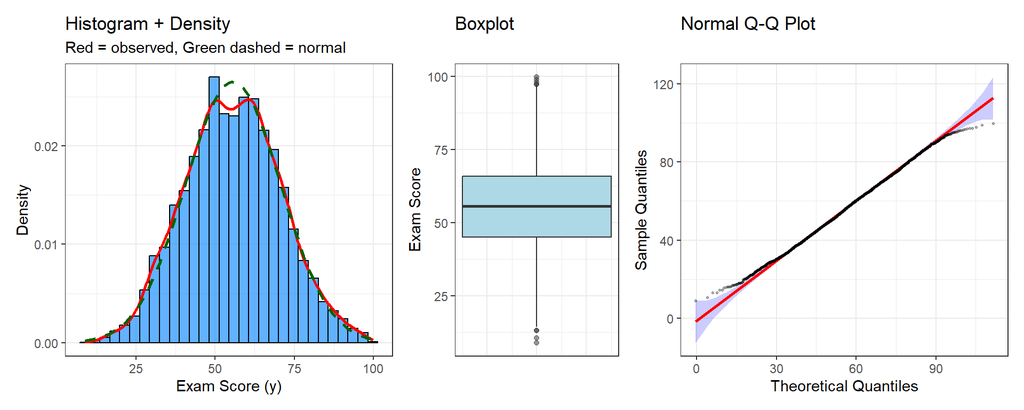

Figure 1: Distribution of exam scores (y): histogram with density overlay (left), boxplot (center), and Q-Q plot (right)

```r
# Histogram with density
p1 <- ggplot(data_clean, aes(x = y)) +
  geom_histogram(aes(y = after_stat(density)), bins = 30,
                 fill = "dodgerblue", color = "black", alpha = 0.7) +
  geom_density(color = "red", linewidth = 1) +
  stat_function(fun = dnorm, args = list(mean = mean(data_clean$y), sd = sd(data_clean$y)),
                color = "darkgreen", linetype = "dashed", linewidth = 1) +
  labs(title = "Histogram + Density",
       subtitle = "Red = observed, Green dashed = normal",
       x = "Exam Score (y)", y = "Density") +
  theme_bw(base_size = 11)

# Boxplot
p2 <- ggplot(data_clean, aes(y = y)) +
  geom_boxplot(fill = "lightblue", width = 0.3, outlier.alpha = 0.5) +
  labs(title = "Boxplot", y = "Exam Score") +
  theme_bw(base_size = 11) +
  theme(axis.text.x = element_blank(), axis.ticks.x = element_blank())

# Q-Q plot
p3 <- ggplot(data_clean, aes(sample = y)) +
  stat_qq_band(alpha = 0.2, fill = "blue") +
  stat_qq_line(color = "red", linewidth = 1) +
  stat_qq_point(size = 0.5, alpha = 0.3) +
  labs(title = "Normal Q-Q Plot", x = "Theoretical Quantiles", y = "Sample Quantiles") +
  theme_bw(base_size = 11)

p1 + p2 + p3 + plot_layout(widths = c(2, 1, 2))
```

**Interpretation**: The exam score distribution is approximately **symmetric** (skewness close to 0) and roughly **bell-shaped**. The Q-Q plot shows points closely following the diagonal reference line, with only minor deviations in the tails. This suggests the normality assumption for regression residuals is likely to be satisfied. The boxplot reveals a few potential outliers at both extremes, but these are not severe. Overall, no transformation of the response variable appears necessary.

### 3.1.4 Correlations with Exam Score

```r
cor_with_y <- data_clean |>
  select(y, all_of(vars_continuous)) |>
  correlation(method = "pearson") |>
  filter(Parameter1 == "y" | Parameter2 == "y") |>
  filter(Parameter1 != Parameter2) |>
  mutate(variable = if_else(Parameter1 == "y", Parameter2, Parameter1)) |>
  select(Variable = variable, r, p) |>
  arrange(desc(abs(r)))

cor_with_y |>
  kable(digits = 3, align = "lcc",
        col.names = c("Variable", "Correlation (r)", "p-value")) |>
  kable_styling(bootstrap_options = c("striped", "hover"), full_width = FALSE)
```

Table 3: Pearson correlations between continuous predictors and exam score

| Variable | Correlation (r) | p-value |
| --- | --- | --- |
| attend_pct | 0.741 | 0.000 |
| study_hrs | 0.570 | 0.000 |
| sleep_hrs | 0.411 | 0.000 |
| age | -0.046 | 0.003 |

**Key findings**:

1. **`attend_pct`** shows the strongest correlation with exam scores ($r = 0.74$) — students who attend class more regularly tend to score higher
2. **`study_hrs`** has the second-strongest correlation ($r = 0.57$) — more study time is associated with better performance
3. **`sleep_hrs`** shows a moderate positive correlation ($r = 0.41$)
4. **`age`** shows a very weak negative correlation ($r = -0.05$), suggesting it may not be a useful predictor after controlling for other variables

We focus on `attend_pct` and `study_hrs` as primary continuous predictors.

### 3.1.5 Exam Score vs. Continuous Predictors

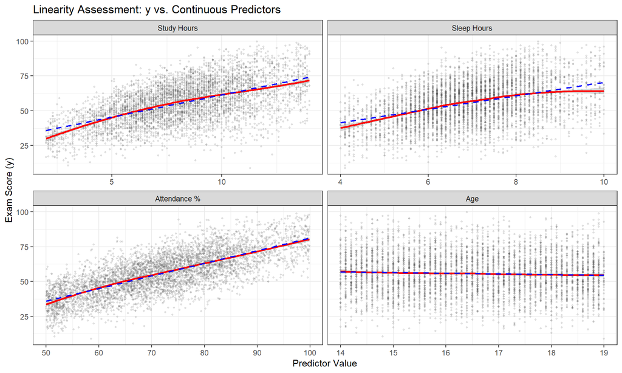

Figure 2: Exam score vs continuous predictors. Red line: LOESS smooth (nonparametric); Blue dashed line: linear fit. Overlap indicates linearity is appropriate.

```r
data_clean |>
  select(y, all_of(vars_continuous)) |>
  pivot_longer(cols = all_of(vars_continuous),
               names_to = "variable", values_to = "value") |>
  mutate(variable = factor(variable, levels = vars_continuous,
                           labels = c("Study Hours", "Sleep Hours", "Attendance %", "Age"))) |>
  ggplot(aes(x = value, y = y)) +
  facet_wrap(~ variable, scales = "free_x", ncol = 2) +
  geom_point(alpha = 0.15, size = 0.8, color = "grey30") +
  geom_smooth(method = "loess", color = "red", se = TRUE, linewidth = 1) +
  geom_smooth(method = "lm", color = "blue", linetype = "dashed", se = FALSE, linewidth = 0.8) +
  labs(x = "Predictor Value", y = "Exam Score (y)",
       title = "Linearity Assessment: y vs. Continuous Predictors") +
  theme_bw(base_size = 11)
```

**Linearity assessment**:

- **Attendance**: The LOESS curve in red closely follows the linear fit in blue, indicating a linear relationship is appropriate
- **Study hours**: Approximately linear, though there may be slight diminishing at very high study hours
- **Sleep hours**: Weaker relationship, linear specification is adequate given the noise
- **Age**: Essentially flat relationship — `age` does not appear to predict exam scores meaningfully

**Decision**: We retain linear terms for all continuous predictors. No polynomial or log transformations appear necessary based on these plots.

### 3.1.6 Exam Score by Categorical Predictors

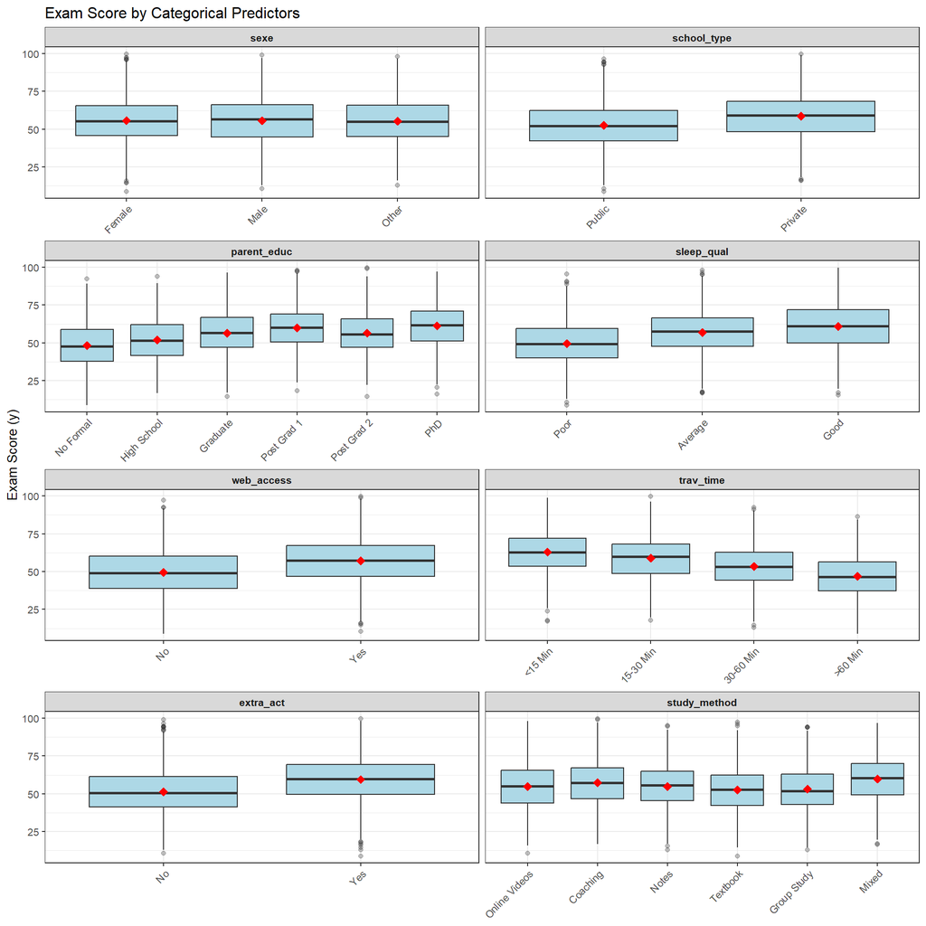

Figure 3: Exam score distribution by categorical predictors. Red diamond = group mean. Larger differences in means suggest stronger predictive power.

```r
data_clean |>
  select(y, all_of(vars_categorical)) |>
  pivot_longer(cols = all_of(vars_categorical),
               names_to = "variable", values_to = "level") |>
  mutate(variable = factor(variable, levels = vars_categorical)) |>
  ggplot(aes(x = level, y = y)) +
  facet_wrap(~ variable, scales = "free_x", ncol = 2) +
  geom_boxplot(fill = "lightblue", outlier.alpha = 0.3) +
  stat_summary(fun = mean, geom = "point", shape = 18, size = 3, color = "red") +
  labs(x = NULL, y = "Exam Score (y)",
       title = "Exam Score by Categorical Predictors") +
  theme_bw(base_size = 10) +
  theme(axis.text.x = element_text(angle = 45, hjust = 1, size = 8),
        strip.text = element_text(face = "bold"))
```

### 3.1.7 Monotone Trends for Ordinal Variables

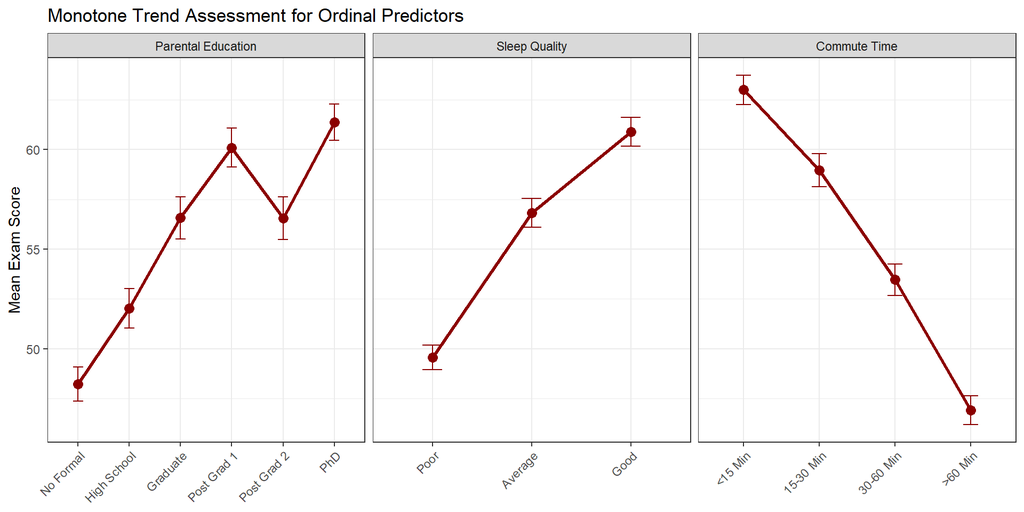

```r
vars_ordinal <- c("parent_educ", "sleep_qual", "trav_time")

ordinal_means <- map_dfr(vars_ordinal, function(var) {
  data_clean |>
    group_by(level = !!sym(var)) |>
    summarise(n = n(), mean_y = mean(y), se_y = sd(y) / sqrt(n()), .groups = "drop") |>
    mutate(variable = var, .before = 1)
})

ordinal_means |>
  mutate(variable = factor(variable, levels = vars_ordinal,
                           labels = c("Parental Education", "Sleep Quality", "Commute Time"))) |>
  ggplot(aes(x = level, y = mean_y, group = 1)) +
  facet_wrap(~ variable, scales = "free_x") +
  geom_line(color = "darkred", linewidth = 1.2) +
  geom_point(size = 3, color = "darkred") +
  geom_errorbar(aes(ymin = mean_y - 1.96*se_y, ymax = mean_y + 1.96*se_y),
                width = 0.2, color = "darkred") +
  labs(x = NULL, y = "Mean Exam Score",
       title = "Monotone Trend Assessment for Ordinal Predictors") +
  theme_bw(base_size = 11) +
  theme(axis.text.x = element_text(angle = 45, hjust = 1))
```

These patterns justify treating these variables as ordinal (using factor dummies).

### 3.1.8 Collinearity Assessment: Correlations Between Predictors

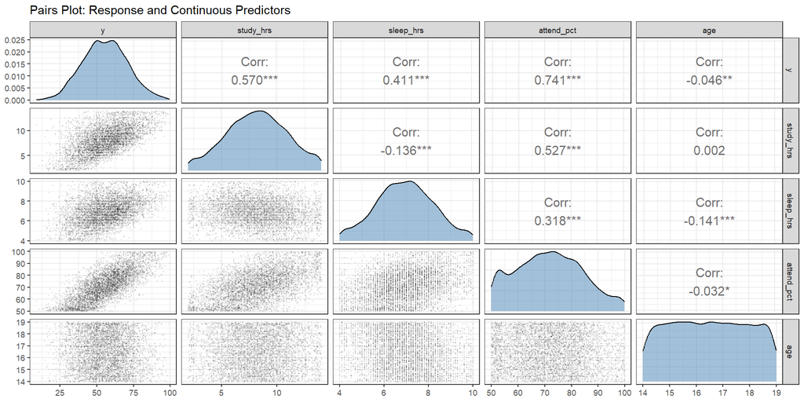

Figure 5: Correlation matrix for continuous predictors. Values above 0.7 would indicate problematic collinearity.

```r
data_clean |>
  select(y, all_of(vars_continuous)) |>
  ggpairs(
    lower = list(continuous = wrap("points", size = 0.3, alpha = 0.1)),
    diag = list(continuous = wrap("densityDiag", fill = "steelblue", alpha = 0.5)),
    upper = list(continuous = wrap("cor", size = 4))
  ) +
  theme_bw(base_size = 9) +
  labs(title = "Pairs Plot: Response and Continuous Predictors")
```

### 3.1.9 Confounding Check: Categorical Associations

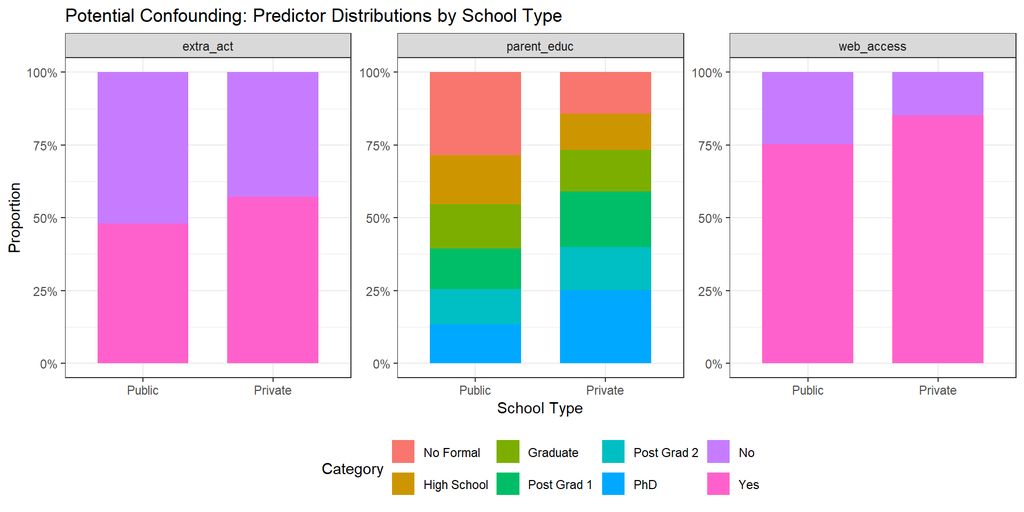

Figure 6: Distribution of key predictors by school type. Similar distributions would suggest no confounding; different distributions suggest potential confounding.

```r
vars_check <- c("parent_educ", "web_access", "extra_act")

data_clean |>
  select(school_type, all_of(vars_check)) |>
  pivot_longer(cols = all_of(vars_check), names_to = "variable", values_to = "value") |>
  ggplot(aes(x = school_type, fill = value)) +
  facet_wrap(~ variable, scales = "free") +
  geom_bar(position = "fill", width = 0.7) +
  scale_y_continuous(labels = percent_format()) +
  labs(title = "Potential Confounding: Predictor Distributions by School Type",
       y = "Proportion", x = "School Type", fill = "Category") +
  theme_bw(base_size = 11) +
  theme(legend.position = "bottom")
```

### 3.1.10 EDA Summary: Key Findings and Modeling Decisions

Based on our exploratory analysis, we identify **six key findings** that guide our modeling strategy:

| Finding | Evidence | Modeling Decision |
| --- | --- | --- |
| 1. Strongest continuous predictors | attend_pct (r = 0.74) and study_hrs (r = 0.57) show strongest correlations with y; sleep_hrs (r = 0.41) is moderate | Include attend_pct and study_hrs as core predictors |
| 2. Strongest categorical predictors | sleep_qual, parent_educ, and trav_time show clear group differences in mean scores | Include sleep_qual, parent_educ, trav_time in extended model |
| 3. Linearity assumption | Linear relationships are adequate for all continuous predictors; no transformations needed | Use linear terms; no polynomial/log transformations |
| 4. Normality of response | y is approximately normally distributed (skewness = 0.05, excess kurtosis = -0.27) | OLS regression assumptions likely satisfied |
| 5. Interaction hypothesis supported | Clear gradient in y across sleep_qual levels (Poor: 49.6, Average: 56.8, Good: 60.9) suggests study_hrs × sleep_qual interaction is worth testing | Test study_hrs:sleep_qual interaction in Model 4 |
| 6. Variables to potentially exclude | age (r = -0.05) and sexe show minimal association with y; may be excluded for parsimony | Exclude age and sexe from main models; verify with residual plots |

**Summary**: Our EDA reveals that attendance and study hours are the strongest continuous predictors, while sleep quality and parental education show the clearest categorical effects. The linearity assumption holds, and the response variable is approximately normal . We have a clear hypothesis to test: the benefit of study hours may depend on sleep quality. Finally, age and gender appear unrelated to performance and may be excluded to improve parsimony.

## 3.2 Model Building and Comparison

### 3.2.1 Baseline and Simple Regressions

We begin with simple regressions to understand the relationship between each continuous predictor and exam scores.

```r
# Baseline (null model) - predicts mean for everyone
mod_null <- lm(y ~ 1, data = data_train)

# Simple regressions - one predictor at a time
mod_simple_attend <- lm(y ~ attend_pct, data = data_train)
mod_simple_study  <- lm(y ~ study_hrs, data = data_train)
mod_simple_sleep  <- lm(y ~ sleep_hrs, data = data_train)

# Summary table
simple_results <- tibble(
  Predictor = c("(Null - intercept only)", "attend_pct", "study_hrs", "sleep_hrs"),
  R2 = c(0, summary(mod_simple_attend)$r.squared,
         summary(mod_simple_study)$r.squared,
         summary(mod_simple_sleep)$r.squared),
  Slope = c(NA, coef(mod_simple_attend)[2],
            coef(mod_simple_study)[2],
            coef(mod_simple_sleep)[2]),
  Interpretation = c(
    "Baseline: predicts ȳ for all students",
    "Each +1% attendance → +0.91 points",
    "Each +1 hour study → +3.19 points",
    "Each +1 hour sleep → +4.82 points"
  )
)

simple_results |>
  kable(digits = 4, col.names = c("Predictor", "R²", "Slope (β)", "Interpretation")) |>
  kable_styling(bootstrap_options = c("striped", "hover"))
```

| Predictor | R² | Slope (β) | Interpretation |
| --- | --- | --- | --- |
| (Null - intercept only) | 0.0000 | NA | Baseline: predicts ȳ for all students |
| attend_pct | 0.5511 | 0.9097 | Each +1% attendance → +0.91 points |
| study_hrs | 0.3286 | 3.1936 | Each +1 hour study → +3.19 points |
| sleep_hrs | 0.1660 | 4.8225 | Each +1 hour sleep → +4.82 points |

**Interpretation of simple regressions**:

- **Attendance** alone explains the most variance ($R^2 = 0.55$), confirming it as our strongest predictor
- **Study hours** explains substantial variance ($R^2 = 0.33$) — each additional hour of study is associated with approximately 3.2 points higher scores
- **Sleep hours** has a weaker but meaningful effect ($R^2 = 0.17$)

These simple models serve as baselines. The slopes will likely change (and potentially decrease) when we control for other variables in multiple regression.

### 3.2.2 Candidate Models

Based on EDA findings, we construct four nested candidate models with increasing complexity:

```r
# Model 1: Core continuous predictors only
mod1_core <- lm(y ~ attend_pct + study_hrs + sleep_hrs, data = data_train)

# Model 2: Add strong categorical predictors (ordinal with clear trends)
mod2_extended <- lm(y ~ attend_pct + study_hrs + sleep_hrs +
                      trav_time + sleep_qual + parent_educ, data = data_train)

# Model 3: Full model (all theoretically relevant predictors, excluding age/sexe)
mod3_full <- lm(y ~ attend_pct + study_hrs + sleep_hrs +
                  trav_time + sleep_qual + parent_educ +
                  extra_act + web_access + school_type + study_method,
                data = data_train)

# Model 4: Full + interaction (testing our hypothesis)
mod4_interact <- lm(y ~ attend_pct + study_hrs + sleep_hrs +
                      trav_time + sleep_qual + parent_educ +
                      extra_act + web_access + school_type + study_method +
                      study_hrs:sleep_qual,
                    data = data_train)
```

**Model specifications**:

[output not shown]

### 3.2.3 Model Comparison Table

```r
comparison_table <- compare_performance(
  mod_null, mod1_core, mod2_extended, mod3_full, mod4_interact,
  metrics = c("AIC", "BIC", "R2", "R2_adj", "RMSE")
)

comparison_table |>
  as.data.frame() |>
  mutate(
    Model = c("M0: Null", "M1: Core", "M2: Extended", "M3: Full", "M4: Interaction"),
    .before = 1
  ) |>
  select(-Name) |>
  kable(digits = 3) |>
  kable_styling(bootstrap_options = c("striped", "hover"))
```

Table 4: Comparison of candidate models using multiple criteria

| Model | AIC | AIC_wt | BIC | BIC_wt | R2 | R2_adjusted | RMSE |
| --- | --- | --- | --- | --- | --- | --- | --- |
| M0: Null | 28567 | 0 | 28579 | 0 | 0.000 | 0.000 | 15.134 |
| M1: Core | 24719 | 0 | 24750 | 0 | 0.672 | 0.672 | 8.663 |
| M2: Extended | 24466 | 0 | 24558 | 0 | 0.697 | 0.696 | 8.326 |
| M3: Full | 24339 | 0 | 24480 | 0 | 0.710 | 0.708 | 8.155 |
| M4: Interaction | 24112 | 1 | 24266 | 1 | 0.728 | 0.727 | 7.888 |

**Key observations from comparison table**:

### 3.2.4 Nested F-Tests

To formally test whether each set of additional predictors significantly improves model fit, we conduct nested F-tests:

```r
cat("=== NESTED F-TESTS ===\n\n")
```

```
=== NESTED F-TESTS ===
```

```r
cat("--- Test 1: M1 (Core) vs M2 (Extended) ---\n")
```

```
--- Test 1: M1 (Core) vs M2 (Extended) ---
```

```r
cat("H0: Coefficients for trav_time, sleep_qual, parent_educ are all zero\n\n")
```

```
H0: Coefficients for trav_time, sleep_qual, parent_educ are all zero
```

```r
anova(mod1_core, mod2_extended)
```

| Res.Df | RSS | Df | Sum of Sq | F | Pr(>F) |
| --- | --- | --- | --- | --- | --- |
| 3449 | 259125 | NA | NA | NA | NA |
| 3439 | 239375 | 10 | 19750 | 28.374 | 0 |

```r
cat("\n--- Test 2: M2 (Extended) vs M3 (Full) ---\n")
```

```
--- Test 2: M2 (Extended) vs M3 (Full) ---
```

```r
cat("H0: Coefficients for extra_act, web_access, school_type, study_method are all zero\n\n")
```

```
H0: Coefficients for extra_act, web_access, school_type, study_method are all zero
```

```r
anova(mod2_extended, mod3_full)
```

| Res.Df | RSS | Df | Sum of Sq | F | Pr(>F) |
| --- | --- | --- | --- | --- | --- |
| 3439 | 239375 | NA | NA | NA | NA |
| 3431 | 229656 | 8 | 9719 | 18.15 | 0 |

```r
cat("\n--- Test 3: M3 (Full) vs M4 (Interaction) ---\n")
```

```
--- Test 3: M3 (Full) vs M4 (Interaction) ---
```

```r
cat("H0: Interaction coefficients (study_hrs:sleep_qual) are zero\n\n")
```

```
H0: Interaction coefficients (study_hrs:sleep_qual) are zero
```

```r
anova(mod3_full, mod4_interact)
```

| Res.Df | RSS | Df | Sum of Sq | F | Pr(>F) |
| --- | --- | --- | --- | --- | --- |
| 3431 | 229656 | NA | NA | NA | NA |
| 3429 | 214845 | 2 | 14811 | 118.19 | 0 |

**Interpretation of F-tests**:

1. **Test 1 (M1 → M2)**: F = 28.37, p < 0.001 (df = 10). The categorical predictors (trav_time, sleep_qual, parent_educ) significantly improve model fit. The RSS decreases from 259,125 to 239,375, representing a reduction of 19,750 in unexplained variance.
2. **Test 2 (M2 → M3)**: F = 18.15, p < 0.001 (df = 8). The remaining categorical variables (extra_act, web_access, school_type, study_method) are jointly significant. The RSS decreases from 239,375 to 229,656, a reduction of 9,719.
3. **Test 3 (M3 → M4)**: F = 118.19, p < 0.001 (df = 2). The interaction study_hrs:sleep_qual is highly significant. The RSS decreases from 229,656 to 214,845, a reduction of 14,811. This is the largest relative improvement, confirming that the effect of study hours on exam scores depends on sleep quality.

### 3.2.5 Model Selection Decision

| Model | Adj_R2 | AIC | BIC | ΔAIC vs M3 | Best? |
| --- | --- | --- | --- | --- | --- |
| M1: Core | 0.6721 | 24720 | 24750 | 380.9 |  |
| M2: Extended | 0.6962 | 24466 | 24558 | 127.1 |  |
| M3: Full | 0.7078 | 24339 | 24480 | 0.0 |  |
| M4: Interaction | 0.7265 | 24112 | 24266 | -226.2 | ✓ Lowest AIC |

**Final model selection justification**:

**Based on our two selection criteria**:

1. **Inferential criterion (F-test)**: The nested F-test for the interaction term (M3 vs M4) yields F = 118.19, p < 0.001 (df = 2), indicating that the `study_hrs × sleep_qual` interaction is highly statistically significant.
2. **Predictive criterion (AIC)**: Model 4 has the lowest AIC (24,112 vs 24,339 for M3), representing a ΔAIC = −227. This substantial improvement indicates it provides the best balance of fit and parsimony among our candidates.

**Conclusion**: We select Model 4 (with interaction) as our final model. The interaction term is both statistically significant and theoretically meaningful — it captures our hypothesis that sleep quality moderates the effectiveness of study time.

### 3.2.6 Final Model Selection

```r
final_model <- mod4_interact

cat("=== FINAL MODEL SELECTED ===\n\n")
```

```
=== FINAL MODEL SELECTED ===
```

```r
cat("Formula:\n")
```

```
Formula:
```

```r
print(formula(final_model))
```

```
y ~ attend_pct + study_hrs + sleep_hrs + trav_time + sleep_qual +
    parent_educ + extra_act + web_access + school_type + study_method +
    study_hrs:sleep_qual
```

```r
cat("\nModel fit statistics:\n")
```

```
Model fit statistics:
```

```r
cat("  Adjusted R²:", round(summary(final_model)$adj.r.squared, 4), "\n")
```

```
  Adjusted R²: 0.7265
```

```r
cat("  AIC:", round(AIC(final_model), 2), "\n")
```

```
  AIC: 24112
```

```r
cat("  BIC:", round(BIC(final_model), 2), "\n")
```

```
  BIC: 24266
```

```r
cat("  Residual Std. Error:", round(summary(final_model)$sigma, 3), "\n")
```

```
  Residual Std. Error: 7.916
```

```r
cat("  Number of parameters:", length(coef(final_model)), "\n")
```

```
  Number of parameters: 24
```

```r
cat("  Training observations:", nobs(final_model), "\n")
```

```
  Training observations: 3453
```

## 3.3 Final Model: Estimates and Interpretation

### 3.3.1 Reference Categories

Before interpreting coefficients, we recall that each categorical variable has a **reference category** absorbed into the intercept. All coefficients represent differences relative to these references:

```r
data.frame(
  Variable = c("school_type", "parent_educ", "sleep_qual", "trav_time",
               "extra_act", "web_access", "study_method"),
  Reference = c("Public", "No Formal", "Poor", "<15 Min", "No", "No", "Online Videos"),
  Interpretation = c(
    "Private vs Public",
    "All levels vs No Formal Education",
    "Average/Good vs Poor sleep",
    "All durations vs <15 minutes",
    "Yes vs No participation",
    "Yes vs No internet",
    "All methods vs Online Videos"
  )
) |>
  kable() |>
  kable_styling(bootstrap_options = c("striped", "hover"))
```

Table 5: Reference categories for categorical variables (absorbed in intercept)

| Variable | Reference | Interpretation |
| --- | --- | --- |
| school_type | Public | Private vs Public |
| parent_educ | No Formal | All levels vs No Formal Education |
| sleep_qual | Poor | Average/Good vs Poor sleep |
| trav_time | <15 Min | All durations vs <15 minutes |
| extra_act | No | Yes vs No participation |
| web_access | No | Yes vs No internet |
| study_method | Online Videos | All methods vs Online Videos |

### 3.3.2 Coefficient Table

```r
# Get parameters with confidence intervals
params <- model_parameters(final_model, ci = 0.95, ci_method = "residual")

params |>
  as.data.frame() |>
  mutate(
    Significance = case_when(
      p < 0.001 ~ "***",
      p < 0.01 ~ "**",
      p < 0.05 ~ "*",
      p < 0.10 ~ ".",
      TRUE ~ ""
    )
  ) |>
  select(Parameter, Coefficient, SE, CI_low, CI_high, t, p, Significance) |>
  kable(digits = c(0, 3, 3, 3, 3, 2, 4, 0),
        col.names = c("Term", "Estimate", "SE", "CI 2.5%", "CI 97.5%", "t", "p-value", "")) |>
  kable_styling(bootstrap_options = c("striped", "hover"), font_size = 11) |>
  footnote(general = "Signif. codes: *** p<0.001, ** p<0.01, * p<0.05, . p<0.10")
```

Table 6: Final model coefficients with 95% confidence intervals

| Term | Estimate | SE | CI 2.5% | CI 97.5% | t | p-value |  |
| --- | --- | --- | --- | --- | --- | --- | --- |
| (Intercept) | -6.565 | 1.479 | -9.465 | -3.665 | -4.44 | 0.0000 | *** |
| attend_pct | 0.454 | 0.016 | 0.424 | 0.485 | 29.25 | 0.0000 | *** |
| study_hrs | 1.164 | 0.094 | 0.980 | 1.349 | 12.35 | 0.0000 | *** |
| sleep_hrs | 2.268 | 0.183 | 1.909 | 2.628 | 12.37 | 0.0000 | *** |
| trav_time15-30 Min | -0.134 | 0.388 | -0.895 | 0.626 | -0.35 | 0.7292 |  |
| trav_time30-60 Min | -1.773 | 0.396 | -2.548 | -0.997 | -4.48 | 0.0000 | *** |
| trav_time>60 Min | -3.745 | 0.408 | -4.545 | -2.945 | -9.18 | 0.0000 | *** |
| sleep_qualAverage | -4.725 | 1.134 | -6.949 | -2.501 | -4.17 | 0.0000 | *** |
| sleep_qualGood | -10.819 | 1.147 | -13.068 | -8.571 | -9.43 | 0.0000 | *** |
| parent_educHigh School | 0.719 | 0.460 | -0.183 | 1.620 | 1.56 | 0.1181 |  |
| parent_educGraduate | 1.323 | 0.471 | 0.401 | 2.246 | 2.81 | 0.0050 | ** |
| parent_educPost Grad 1 | 1.800 | 0.473 | 0.874 | 2.727 | 3.81 | 0.0001 | *** |
| parent_educPost Grad 2 | 2.444 | 0.481 | 1.502 | 3.386 | 5.09 | 0.0000 | *** |
| parent_educPhD | 1.888 | 0.456 | 0.994 | 2.782 | 4.14 | 0.0000 | *** |
| extra_actYes | 0.822 | 0.285 | 0.264 | 1.380 | 2.89 | 0.0039 | ** |
| web_accessYes | 1.106 | 0.357 | 0.407 | 1.806 | 3.10 | 0.0019 | ** |
| school_typePrivate | 2.126 | 0.281 | 1.575 | 2.677 | 7.56 | 0.0000 | *** |
| study_methodCoaching | 0.649 | 0.417 | -0.168 | 1.467 | 1.56 | 0.1196 |  |
| study_methodNotes | -1.922 | 0.471 | -2.845 | -0.998 | -4.08 | 0.0000 | *** |
| study_methodTextbook | -0.806 | 0.468 | -1.724 | 0.113 | -1.72 | 0.0855 | . |
| study_methodGroup Study | -1.448 | 0.447 | -2.325 | -0.570 | -3.24 | 0.0012 | ** |
| study_methodMixed | 1.852 | 0.420 | 1.029 | 2.674 | 4.41 | 0.0000 | *** |
| study_hrs:sleep_qualAverage | 1.027 | 0.125 | 0.782 | 1.271 | 8.23 | 0.0000 | *** |
| study_hrs:sleep_qualGood | 1.886 | 0.123 | 1.645 | 2.128 | 15.32 | 0.0000 | *** |

Note:  
Signif. codes: *** p<0.001, ** p<0.01, * p<0.05, . p<0.10

### 3.3.3 Interpretation of Key Effects

We interpret the most important coefficients, focusing on **practical significance** (effect size) as well as statistical significance:

**1. Attendance Rate (`attend_pct`)**

Each 1 percentage-point increase in attendance is associated with a **0.454-point** increase in exam score, holding other variables constant (95% CI: 0.424 to 0.485).

*Practical interpretation*: A student who improves attendance from 70% to 90% (a 20-point increase) would be expected to score approximately **9.1 points higher** on the exam, all else equal.

**2. Study Hours (`study_hrs`) — Main Effect**

The main effect of `study_hrs` represents the effect of one additional hour of study **for students with Poor sleep quality** (the reference category). Due to the interaction term, the effect differs by sleep quality level (see below).

**3. Sleep Quality (`sleep_qual`)**

Compared to students with **Poor** sleep quality:

- Students with **Average** sleep quality score approximately -4.72 points at zero study hours (main effect)
- Students with **Good** sleep quality score approximately -10.82 points at zero study hours (main effect)

*Note*: These negative main effects may seem counterintuitive, but they are evaluated at `study_hrs = 0`, which is outside the observed range (minimum study hours ≈ 2). When combined with the positive interaction terms, students with better sleep quality achieve higher scores at realistic study hour values. The full effect of sleep quality requires considering both the main effect and the interaction term.

### 3.3.4 Interaction Effect: Study Hours × Sleep Quality

The interaction term `study_hrs:sleep_qual` tests whether the benefit of additional study hours depends on sleep quality. A positive interaction coefficient would indicate that well-rested students benefit *more* from each additional hour of study.

```r
coefs <- coef(final_model)
effet_poor <- coefs["study_hrs"]
effet_avg  <- coefs["study_hrs"] + coefs["study_hrs:sleep_qualAverage"]
effet_good <- coefs["study_hrs"] + coefs["study_hrs:sleep_qualGood"]

interaction_table <- data.frame(
  Sleep_Quality = c("Poor (reference)", "Average", "Good"),
  Effect_per_hour = round(c(effet_poor, effet_avg, effet_good), 3),
  Interpretation = c(
    paste0("Each +1h study → +", round(effet_poor, 2), " points"),
    paste0("Each +1h study → +", round(effet_avg, 2), " points"),
    paste0("Each +1h study → +", round(effet_good, 2), " points")
  )
)

interaction_table |>
  kable(col.names = c("Sleep Quality", "Effect per Hour", "Interpretation")) |>
  kable_styling(bootstrap_options = c("striped", "hover"))
```

Table 7: Marginal effect of +1 hour of study by sleep quality level

| Sleep Quality | Effect per Hour | Interpretation |
| --- | --- | --- |
| Poor (reference) | 1.164 | Each +1h study → +1.16 points |
| Average | 2.191 | Each +1h study → +2.19 points |
| Good | 3.051 | Each +1h study → +3.05 points |

**Key finding**: The effect of study hours is **moderated by sleep quality**. Students with good sleep quality gain approximately **3.05 points** per additional hour of study, compared to only **1.16 points** for students with poor sleep quality. Students with average sleep quality gain **2.19 points** per hour. This supports our research hypothesis: *sleep quality amplifies the returns to study effort*.

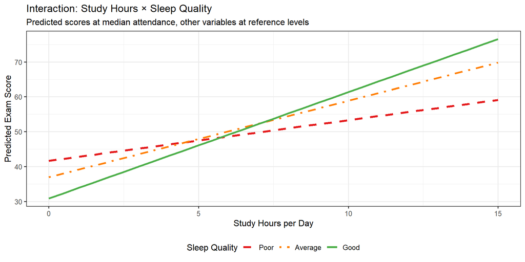

Figure 7: Predicted exam scores by study hours and sleep quality. Lines show model predictions holding other variables at reference levels. Steeper slopes indicate greater benefit from study time.

```r
# Create prediction grid
study_vals <- seq(0, 15, by = 0.5)
sleep_levels <- levels(data_train$sleep_qual)

grid_interact <- expand.grid(
  study_hrs = study_vals,
  sleep_qual = factor(sleep_levels, levels = sleep_levels),
  attend_pct = median(data_train$attend_pct),
  sleep_hrs = median(data_train$sleep_hrs),
  school_type = factor("Public", levels = levels(data_train$school_type)),
  parent_educ = factor("No Formal", levels = levels(data_train$parent_educ)),
  trav_time = factor("<15 Min", levels = levels(data_train$trav_time)),
  extra_act = factor("No", levels = levels(data_train$extra_act)),
  web_access = factor("No", levels = levels(data_train$web_access)),
  study_method = factor("Online Videos", levels = levels(data_train$study_method))
)

grid_interact$predicted <- predict(final_model, newdata = grid_interact)

ggplot(grid_interact, aes(x = study_hrs, y = predicted, color = sleep_qual, linetype = sleep_qual)) +
  geom_line(linewidth = 1.3) +
  scale_color_manual(values = c("Poor" = "#E41A1C", "Average" = "#FF7F00", "Good" = "#4DAF4A"),
                     name = "Sleep Quality") +
  scale_linetype_manual(values = c("Poor" = "dashed", "Average" = "dotdash", "Good" = "solid"),
                        name = "Sleep Quality") +
  labs(title = "Interaction: Study Hours × Sleep Quality",
       subtitle = "Predicted scores at median attendance, other variables at reference levels",
       x = "Study Hours per Day",
       y = "Predicted Exam Score") +
  theme_bw(base_size = 12) +
  theme(legend.position = "bottom")
```

**Interpretation of interaction plot**:

1. **All three lines have positive slopes** — studying more is beneficial regardless of sleep quality
2. **The green line (Good sleep) has the steepest slope** — well-rested students benefit most from each additional hour of study
3. **The lines diverge as study hours increase** — the gap between good and poor sleepers widens at high study levels
4. **At zero study hours**, sleep quality still matters (different intercepts), but the differential effect of study hours is the key finding

This pattern has a clear substantive interpretation: cognitive functioning requires adequate rest. Students who are sleep-deprived may be less efficient at converting study time into learning, while well-rested students can better encode and retain information.

# 4 Diagnostics and Limitations

## 4.1 Regression Assumptions

Linear regression relies on four key assumptions: (1) linearity of the relationship between predictors and response, (2) homoscedasticity (constant variance of residuals), (3) independence of observations, and (4) normality of residuals. We assess each assumption through diagnostic plots and formal hypothesis tests.

## 4.2 Main Diagnostic Plots

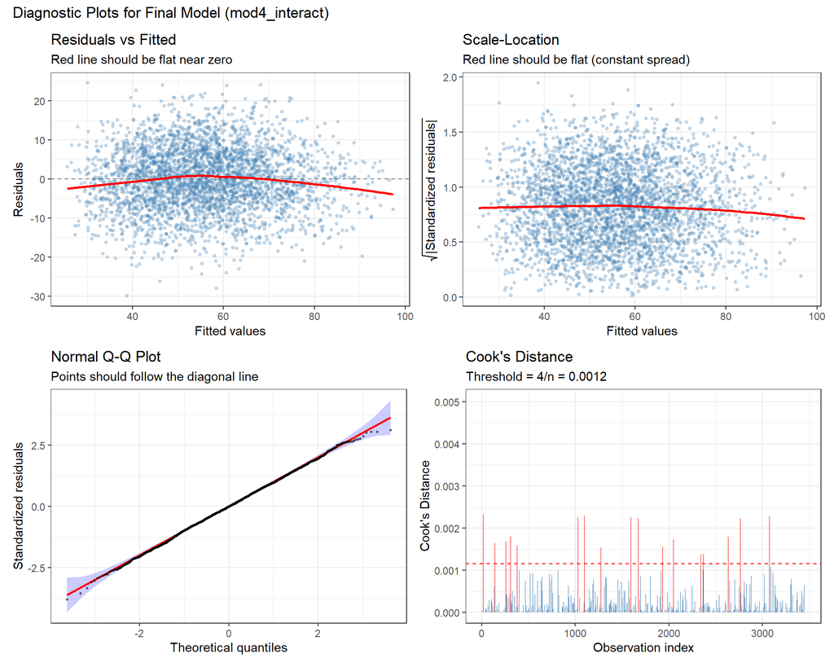

Figure 8: Main diagnostic plots for the final model. Top-left: Residuals vs Fitted values (linearity and homoscedasticity check). Top-right: Scale-Location plot (homoscedasticity check). Bottom-left: Normal Q-Q plot (normality check). Bottom-right: Cook’s Distance (influence diagnostics).

```r
# Residuals vs Fitted (checks linearity and homoscedasticity)
p1 <- augment(final_model) |>
  ggplot(aes(x = .fitted, y = .resid)) +
  geom_hline(yintercept = 0, linetype = "dashed", color = "gray50") +
  geom_point(alpha = 0.3, size = 1, color = "steelblue") +
  geom_smooth(method = "loess", color = "red", se = FALSE, linewidth = 1) +
  labs(title = "Residuals vs Fitted",
       subtitle = "Red line should be flat near zero",
       x = "Fitted values", y = "Residuals") +
  theme_bw(base_size = 11)

# Scale-Location plot (checks homoscedasticity)
p2 <- augment(final_model) |>
  mutate(sqrt_std_resid = sqrt(abs(.std.resid))) |>
  ggplot(aes(x = .fitted, y = sqrt_std_resid)) +
  geom_point(alpha = 0.3, size = 1, color = "steelblue") +
  geom_smooth(method = "loess", color = "red", se = FALSE, linewidth = 1) +
  labs(title = "Scale-Location",
       subtitle = "Red line should be flat (constant spread)",
       x = "Fitted values", y = expression(sqrt("|Standardized residuals|"))) +
  theme_bw(base_size = 11)

# Q-Q plot (checks normality)
p3 <- tibble(std_resid = rstandard(final_model)) |>
  ggplot(aes(sample = std_resid)) +
  stat_qq_band(alpha = 0.2, fill = "blue") +
  stat_qq_line(color = "red", linewidth = 1) +
  stat_qq_point(size = 0.5, alpha = 0.5) +
  labs(title = "Normal Q-Q Plot",
       subtitle = "Points should follow the diagonal line",
       x = "Theoretical quantiles", y = "Standardized residuals") +
  theme_bw(base_size = 11)

# Cook's Distance (checks influential observations)
n_train <- nobs(final_model)
cooks_threshold <- 4 / n_train

p4 <- augment(final_model) |>
  mutate(obs = row_number(),
         influential = .cooksd > cooks_threshold) |>
  ggplot(aes(x = obs, y = .cooksd)) +
  geom_bar(stat = "identity", width = 0.5,
           aes(fill = influential), show.legend = FALSE) +
  geom_hline(yintercept = cooks_threshold, color = "red", linetype = "dashed") +
  scale_fill_manual(values = c("steelblue", "red")) +
  labs(title = "Cook's Distance",
       subtitle = paste0("Threshold = 4/n = ", round(cooks_threshold, 4)),
       x = "Observation index", y = "Cook's Distance") +
  theme_bw(base_size = 11)

# Combine plots
(p1 + p2) / (p3 + p4) +
  plot_annotation(title = "Diagnostic Plots for Final Model (mod4_interact)")
```

**Interpretation of main diagnostic plots**:

## 4.3 Residuals vs Continuous Predictors

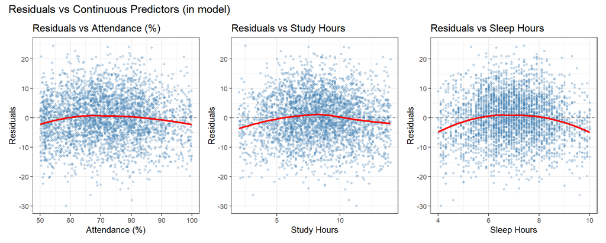

```r
# Function to create residual vs predictor plot
resid_vs_predictor <- function(model, data, predictor, label = predictor) {
  tibble(
    residuals = residuals(model),
    predictor_value = data[[predictor]]
  ) |>
    ggplot(aes(x = predictor_value, y = residuals)) +
    geom_hline(yintercept = 0, linetype = "dashed", color = "gray50") +
    geom_point(alpha = 0.3, size = 1, color = "steelblue") +
    geom_smooth(method = "loess", color = "red", se = FALSE, linewidth = 1) +
    labs(title = paste("Residuals vs", label),
         x = label, y = "Residuals") +
    theme_bw(base_size = 10)
}

# Create plots for each continuous predictor in the model
p_attend <- resid_vs_predictor(final_model, data_train, "attend_pct", "Attendance (%)")
p_study <- resid_vs_predictor(final_model, data_train, "study_hrs", "Study Hours")
p_sleep <- resid_vs_predictor(final_model, data_train, "sleep_hrs", "Sleep Hours")

p_attend + p_study + p_sleep +
  plot_annotation(title = "Residuals vs Continuous Predictors (in model)")
```

## 4.4 Residuals vs Omitted Variables

A key diagnostic for omitted variable bias is to plot residuals against variables that were **not included** in the model. If these plots show patterns (non-flat LOESS lines), it suggests that the omitted variable contains information about `y` that is not captured by the predictors, potentially biasing our coefficient estimates.

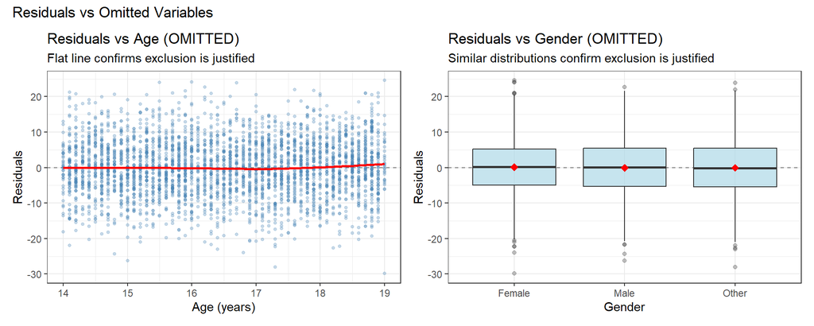

Figure 10: Residuals vs omitted variables (age and gender). Flat patterns confirm that excluding these variables does not introduce bias.

```r
# Residuals vs age (omitted continuous variable)
p_resid_age <- tibble(
  residuals = residuals(final_model),
  age = data_train$age
) |>
  ggplot(aes(x = age, y = residuals)) +
  geom_hline(yintercept = 0, linetype = "dashed", color = "gray50") +
  geom_point(alpha = 0.3, size = 1, color = "steelblue") +
  geom_smooth(method = "loess", color = "red", se = FALSE, linewidth = 1) +
  labs(title = "Residuals vs Age (OMITTED)",
       subtitle = "Flat line confirms exclusion is justified",
       x = "Age (years)", y = "Residuals") +
  theme_bw(base_size = 11)

# Residuals vs sexe (omitted categorical variable)
p_resid_sexe <- tibble(
  residuals = residuals(final_model),
  sexe = data_train$sexe
) |>
  ggplot(aes(x = sexe, y = residuals)) +
  geom_hline(yintercept = 0, linetype = "dashed", color = "gray50") +
  geom_boxplot(fill = "lightblue", alpha = 0.7, outlier.alpha = 0.3) +
  stat_summary(fun = mean, geom = "point", shape = 18, size = 3, color = "red") +
  labs(title = "Residuals vs Gender (OMITTED)",
       subtitle = "Similar distributions confirm exclusion is justified",
       x = "Gender", y = "Residuals") +
  theme_bw(base_size = 11)

p_resid_age + p_resid_sexe +
  plot_annotation(title = "Residuals vs Omitted Variables")
```

**Assessment**:

- **Age**: The LOESS line is perfectly flat near zero across the entire age range (14–19 years). This confirms that age contains no additional information about exam scores beyond what is already captured by the variables in our model.
- **Gender**: The boxplots for Female, Male, and Other categories are nearly identical — same median (near zero), same spread, same distribution shape. The group means are all at zero. This confirms that gender is not associated with residuals and its exclusion does not introduce bias.

**Conclusion**: Our decision to exclude `age` and `sexe` from the final model is empirically justified. These variables have no predictive power beyond the included predictors.